# Week 2 - Preprocessing, part 2

# 1. Lesson: None

# 2. Weekly graph question

The Storytelling With Data book mentions planning on a "Who, What, and How" for your data story. Write down a possible Who, What, and How for your data, using the ideas in the book.

```python
# Who - International policymakers and education leaders who allocate funding
#        to improve equity in primary education, particularly in low- and middle-income communities.

# What - Although global primary education rates have increased over time,
#        inequities and access gaps still persist in low- and middle-income countries.

# How - Use World Bank Education Statistics to create clear line graphs
#        showing enrollment trends over time and bar charts comparing regions
#        or income groups to highlight where gaps remain.
```

```python
import pandas as pd

df = pd.read_csv("EdStatsData.csv (2).zip", compression="zip")
df.head()
```

|  | Country Name | Country Code | Indicator Name | Indicator Code | 1970 | 1971 | 1972 | 1973 | 1974 | 1975 | ... | 2060 | 2065 | 2070 | 2075 | 2080 | 2085 | 2090 | 2095 | 2100 | Unnamed: 69 |
| --- | --- | --- | --- | --- | --- | --- | --- | --- | --- | --- | --- | --- | --- | --- | --- | --- | --- | --- | --- | --- | --- |
| 0 | Arab World | ARB | Adjusted net enrolment rate, lower secondary, ... | UIS.NERA.2 | NaN | NaN | NaN | NaN | NaN | NaN | ... | NaN | NaN | NaN | NaN | NaN | NaN | NaN | NaN | NaN | NaN |
| 1 | Arab World | ARB | Adjusted net enrolment rate, lower secondary, ... | UIS.NERA.2.F | NaN | NaN | NaN | NaN | NaN | NaN | ... | NaN | NaN | NaN | NaN | NaN | NaN | NaN | NaN | NaN | NaN |
| 2 | Arab World | ARB | Adjusted net enrolment rate, lower secondary, ... | UIS.NERA.2.GPI | NaN | NaN | NaN | NaN | NaN | NaN | ... | NaN | NaN | NaN | NaN | NaN | NaN | NaN | NaN | NaN | NaN |
| 3 | Arab World | ARB | Adjusted net enrolment rate, lower secondary, ... | UIS.NERA.2.M | NaN | NaN | NaN | NaN | NaN | NaN | ... | NaN | NaN | NaN | NaN | NaN | NaN | NaN | NaN | NaN | NaN |
| 4 | Arab World | ARB | Adjusted net enrolment rate, primary, both sex... | SE.PRM.TENR | 54.822121 | 54.894138 | 56.209438 | 57.267109 | 57.991138 | 59.36554 | ... | NaN | NaN | NaN | NaN | NaN | NaN | NaN | NaN | NaN | NaN |

5 rows × 70 columns

```python
df.info()
df.describe()
```

```
<class 'pandas.DataFrame'>
RangeIndex: 886930 entries, 0 to 886929
Data columns (total 70 columns):
 #   Column          Non-Null Count   Dtype
---  ------          --------------   -----
 0   Country Name    886930 non-null  str
 1   Country Code    886930 non-null  str
 2   Indicator Name  886930 non-null  str
 3   Indicator Code  886930 non-null  str
 4   1970            72288 non-null   float64
 5   1971            35537 non-null   float64
 6   1972            35619 non-null   float64
 7   1973            35545 non-null   float64
 8   1974            35730 non-null   float64
 9   1975            87306 non-null   float64
```

[output cut: 62 more lines]

|  | 1970 | 1971 | 1972 | 1973 | 1974 | 1975 | 1976 | 1977 | 1978 | 1979 | ... | 2060 | 2065 | 2070 | 2075 | 2080 | 2085 | 2090 | 2095 | 2100 | Unnamed: 69 |
| --- | --- | --- | --- | --- | --- | --- | --- | --- | --- | --- | --- | --- | --- | --- | --- | --- | --- | --- | --- | --- | --- |
| count | 7.228800e+04 | 3.553700e+04 | 3.561900e+04 | 3.554500e+04 | 3.573000e+04 | 8.730600e+04 | 3.748300e+04 | 3.757400e+04 | 3.757600e+04 | 3.680900e+04 | ... | 5.143600e+04 | 5.143600e+04 | 5.143600e+04 | 5.143600e+04 | 5.143600e+04 | 5.143600e+04 | 5.143600e+04 | 5.143600e+04 | 5.143600e+04 | 0.0 |
| mean | 1.974772e+09 | 4.253638e+09 | 4.592365e+09 | 5.105006e+09 | 5.401493e+09 | 2.314288e+09 | 5.731808e+09 | 6.124437e+09 | 6.671489e+09 | 7.436724e+09 | ... | 7.224868e+02 | 7.271290e+02 | 7.283779e+02 | 7.266484e+02 | 7.228327e+02 | 7.176899e+02 | 7.113072e+02 | 7.034274e+02 | 6.940296e+02 | NaN |
| std | 1.211687e+11 | 1.804814e+11 | 1.914083e+11 | 2.059170e+11 | 2.112150e+11 | 1.375059e+11 | 2.215546e+11 | 2.325489e+11 | 2.473986e+11 | 2.660957e+11 | ... | 2.215845e+04 | 2.287990e+04 | 2.352338e+04 | 2.408149e+04 | 2.455897e+04 | 2.496587e+04 | 2.530183e+04 | 2.556069e+04 | 2.574189e+04 | NaN |
| min | -1.435564e+00 | -1.594625e+00 | -3.056522e+00 | -4.032582e+00 | -4.213563e+00 | -3.658569e+00 | -2.950945e+00 | -3.174870e+00 | -3.558749e+00 | -2.973612e+00 | ... | -1.630000e+00 | -1.440000e+00 | -1.260000e+00 | -1.090000e+00 | -9.200000e-01 | -7.800000e-01 | -6.500000e-01 | -5.500000e-01 | -4.500000e-01 | NaN |
| 25% | 8.900000e-01 | 8.853210e+00 | 9.240920e+00 | 9.595200e+00 | 9.861595e+00 | 1.400000e+00 | 9.312615e+00 | 9.519913e+00 | 1.000000e+01 | 1.000000e+01 | ... | 3.000000e-02 | 3.000000e-02 | 2.000000e-02 | 2.000000e-02 | 1.000000e-02 | 1.000000e-02 | 1.000000e-02 | 1.000000e-02 | 1.000000e-02 | NaN |
| 50% | 6.317724e+00 | 6.316240e+01 | 6.655139e+01 | 6.969595e+01 | 7.087760e+01 | 9.677420e+00 | 7.101590e+01 | 7.133326e+01 | 7.290512e+01 | 7.510173e+01 | ... | 2.300000e-01 | 2.300000e-01 | 2.300000e-01 | 2.300000e-01 | 2.300000e-01 | 2.300000e-01 | 2.300000e-01 | 2.300000e-01 | 2.200000e-01 | NaN |
| 75% | 6.251250e+01 | 5.655200e+04 | 5.863650e+04 | 6.202900e+04 | 6.383675e+04 | 7.854163e+01 | 5.682800e+04 | 5.739175e+04 | 5.940425e+04 | 6.411500e+04 | ... | 7.505000e+00 | 7.500000e+00 | 7.300000e+00 | 7.100000e+00 | 6.722500e+00 | 6.080000e+00 | 5.462500e+00 | 4.680000e+00 | 4.032500e+00 | NaN |
| max | 1.903929e+13 | 1.986457e+13 | 2.100916e+13 | 2.238367e+13 | 2.282991e+13 | 2.300634e+13 | 2.424128e+13 | 2.521383e+13 | 2.622101e+13 | 2.730873e+13 | ... | 2.951569e+06 | 3.070879e+06 | 3.169711e+06 | 3.246239e+06 | 3.301586e+06 | 3.337871e+06 | 3.354746e+06 | 3.351887e+06 | 3.330484e+06 | NaN |

8 rows × 66 columns

The dataset contains educational indicators collected through multiple countries over multiple years from the World Bank. Each row represents a country and indicator combination, while the columns representing the metadata represent the yearly values. Most of the year columns are numerical while the country and indicator are categorical. This dataset is large and spans across multiple decades.

```python
df.duplicated().sum()
```

```
np.int64(0)
```

No duplicated rows were found showing that every row had a unique country-indicator combination.

```python
df.duplicated(subset=["Country Name", "Indicator Name"]).sum()
```

```
np.int64(0)
```

Each country-indicator should have appear only once. I double checked and there are no duplicate combinations.

```python
df.isnull().sum()
```

```
Country Name           0
Country Code           0
Indicator Name         0
Indicator Code         0
1970              814642
                   ...
2085              835494
2090              835494
2095              835494
2100              835494
Unnamed: 69       886930
Length: 70, dtype: int64
```

There are many missing values across year columns. Some years haven't even happened yet as demonstrated with 2085 - 2100. Also, not all countries report each educational indicator every year. Removing all the missing values would significantly reduce the dataset. I figured it would make more sense to focus on a specific indicator and time range to minimize the impact of the missing data.

```python
indicator_name = "Adjusted net enrolment rate, primary, both sexes (%)"

primary_2000 = df[df["Indicator Name"] == indicator_name]["2000"]

primary_2000.mean()
```

```
np.float64(86.06400912516825)
```

```python
indicator_name = "Adjusted net enrolment rate, primary, both sexes (%)"

primary_2000 = df[df["Indicator Name"] == indicator_name]["2000"]

primary_2000.median()
```

```
np.float64(94.02507400512695)
```

```python
indicator_name = "Adjusted net enrolment rate, primary, both sexes (%)"

primary_2000 = df[df["Indicator Name"] == indicator_name]["2000"]

primary_2000.mode()
```

```
0      25.892570
1      27.381390
2      36.261780
3      36.745659
4      40.156040
         ...
143    99.875809
144    99.922050
145    99.952347
146    99.953278
147    99.970207
Name: 2000, Length: 148, dtype: float64
```

For the indicator "Adjusted net enrolment rate, primary, both sex (%)" in the year 2000, the mean enrollment rate across all the countries was 86.06% while the median was 94.03%. The median is higher than the mean, which suggests that many countries had high enrollment rates, while a smaller number of countries with much lower rates brought the average down. There was no clear mode because each country had a different value. Overall, this shows that enrollment levels varied across countries and that disparities in primary school access still existed at the time.

```python
df[df["2010"] < 0]
df[df["2010"] > 100]
```

|  | Country Name | Country Code | Indicator Name | Indicator Code | 1970 | 1971 | 1972 | 1973 | 1974 | 1975 | ... | 2060 | 2065 | 2070 | 2075 | 2080 | 2085 | 2090 | 2095 | 2100 | Unnamed: 69 |
| --- | --- | --- | --- | --- | --- | --- | --- | --- | --- | --- | --- | --- | --- | --- | --- | --- | --- | --- | --- | --- | --- |
| 17 | Arab World | ARB | Adult illiterate population, 15+ years, both s... | UIS.LP.AG15T99 | NaN | NaN | NaN | NaN | NaN | NaN | ... | NaN | NaN | NaN | NaN | NaN | NaN | NaN | NaN | NaN | NaN |
| 18 | Arab World | ARB | Adult illiterate population, 15+ years, female... | UIS.LP.AG15T99.F | NaN | NaN | NaN | NaN | NaN | NaN | ... | NaN | NaN | NaN | NaN | NaN | NaN | NaN | NaN | NaN | NaN |
| 19 | Arab World | ARB | Adult illiterate population, 15+ years, male (... | UIS.LP.AG15T99.M | NaN | NaN | NaN | NaN | NaN | NaN | ... | NaN | NaN | NaN | NaN | NaN | NaN | NaN | NaN | NaN | NaN |
| 703 | Arab World | ARB | Early school leavers from primary education, b... | UIS.ESL.1.T | 2867935.0 | 1134606.0 | 1193009.0 | 1259763.0 | 1221188.0 | 1287423.0 | ... | NaN | NaN | NaN | NaN | NaN | NaN | NaN | NaN | NaN | NaN |
| 704 | Arab World | ARB | Early school leavers from primary education, f... | UIS.ESL.1.F | 1154995.0 | 508457.0 | 535956.0 | 571461.0 | 559398.0 | 598338.0 | ... | NaN | NaN | NaN | NaN | NaN | NaN | NaN | NaN | NaN | NaN |
| ... | ... | ... | ... | ... | ... | ... | ... | ... | ... | ... | ... | ... | ... | ... | ... | ... | ... | ... | ... | ... | ... |
| 886917 | Zimbabwe | ZWE | Wittgenstein Projection: Population in thousan... | PRJ.POP.ALL.1.MA | NaN | NaN | NaN | NaN | NaN | NaN | ... | 212.14 | 179.40 | 150.11 | 126.43 | 106.82 | 91.70 | 78.21 | 67.56 | 59.06 | NaN |
| 886918 | Zimbabwe | ZWE | Wittgenstein Projection: Population in thousan... | PRJ.POP.ALL.1.MF | NaN | NaN | NaN | NaN | NaN | NaN | ... | 494.23 | 420.47 | 352.09 | 294.10 | 244.68 | 205.47 | 171.39 | 144.86 | 124.17 | NaN |
| 886919 | Zimbabwe | ZWE | Wittgenstein Projection: Population in thousan... | PRJ.POP.ALL.3.FE | NaN | NaN | NaN | NaN | NaN | NaN | ... | 3469.66 | 3493.32 | 3491.72 | 3468.64 | 3429.54 | 3378.61 | 3317.67 | 3248.91 | 3175.64 | NaN |
| 886920 | Zimbabwe | ZWE | Wittgenstein Projection: Population in thousan... | PRJ.POP.ALL.3.MA | NaN | NaN | NaN | NaN | NaN | NaN | ... | 3106.84 | 3078.78 | 3041.50 | 3000.74 | 2961.23 | 2924.73 | 2889.02 | 2851.65 | 2813.31 | NaN |
| 886921 | Zimbabwe | ZWE | Wittgenstein Projection: Population in thousan... | PRJ.POP.ALL.3.MF | NaN | NaN | NaN | NaN | NaN | NaN | ... | 6576.50 | 6572.10 | 6533.22 | 6469.39 | 6390.77 | 6303.34 | 6206.69 | 6100.56 | 5988.95 | NaN |

76271 rows × 70 columns

The dataset contains many missing values in earlier years and includes projection data extending far into the future. There is also an extra column (“Unnamed: 69”) that contains only null values. These issues do not make the dataset unusable, but they require cleaning and careful selection of relevant years and indicators.

```python
df_encoded = pd.get_dummies(df, columns=["Country Name"], drop_first=True)
```

I applied one-hot encoding to categorical variables to demonstrate how the dataset could be prepared for modeling purposes.

# 3. Homework - work with your own data

```python
import pandas as pd
import numpy as np
from datetime import datetime, timedelta
```

This week, you will do the same types of exercises as last week, but you should use your chosen datasets that someone in your class found last semester. (They likely will not be the particular datasets that you found yourself.)

### Here are some types of analysis you can do Use Google, documentation, and ChatGPT to help you:

- Summarize the datasets using info() and describe()
- Are there any duplicate rows?
- Are there any duplicate values in a given column (when this would be inappropriate?)
- What are the mean, median, and mode of each column?
- Are there any missing or null values?
  - Do you want to fill in the missing value with a mean value? A value of your choice? Remove that row?
- Identify any other inconsistent data (e.g. someone seems to be taking an action before they are born.)
- Encode any categorical variables (e.g. with one-hot encoding.)

### Conclusions:

- Are the data usable? If not, find some new data!
- Do you need to modify or correct the data in some way?
- Is there any class imbalance? (Categories that have many more items than other categories).

# 4. Storytelling With Data graph

Just like last week: choose any graph in the Introduction of Storytelling With Data. Use matplotlib to reproduce it in a rough way. I don't expect you to spend an enormous amount of time on this; I understand that you likely will not have time to re-create every feature of the graph. However, if you're excited about learning to use matplotlib, this is a good way to do that. You don't have to duplicate the exact values on the graph; just the same rough shape will be enough. If you don't feel comfortable using matplotlib yet, do the best you can and write down what you tried or what Google searches you did to find the answers.

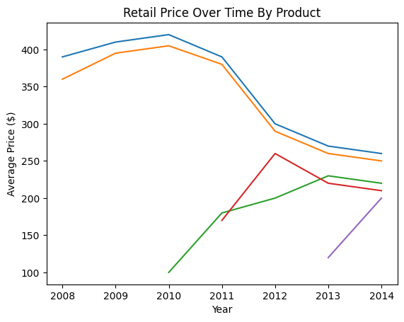

```python
import matplotlib.pyplot as plt

years = np.arange(2008, 2015)

A = [390, 410, 420, 390, 300, 270, 260]
B = [360, 395, 405, 380, 290, 260, 250]
C = [None, None, 100, 180, 200, 230, 220]
D = [None, None, None, 170, 260, 220, 210]
E = [None, None, None, None, None, 120, 200]

plt.figure()

plt.plot(years, A)
plt.plot(years, B)
plt.plot(years, C)
plt.plot(years, D)
plt.plot(years, E)

plt.title("Retail Price Over Time By Product")
plt.xlabel("Year")
plt.ylabel("Average Price ($)")

plt.show()
```

I chose to recreate the line chart on page 6 because it clearly demonstrates how chart type influences interpretation. A line chart is more appropriate for showing trends over time, as it allows the viewer to track changes year by year. In contrast, the original bar chart made it harder to see overall patterns. By converting it to a line chart, the trends become more visible and the message becomes clearer.